# Démo

Graphiques (HTML)

Rédigé et révisé par

Affiliations

Mise à jour

avril 2026

Résumé

**Avant propos**

Un article dédié à la visualisation graphique.

# Pigeons de course

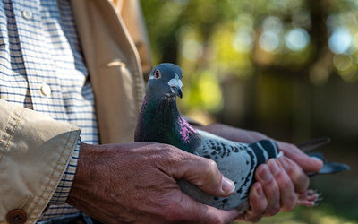

Figure 1: Pigeon voyageur.

L’[American Racing Pigeon Union](https://www.pigeon.org/) dispose d’une excellente base de données les résultats de ses courses.

```r
pigeon <- readr::read_csv("data/pigeons.csv")

pigeon

str(pigeon)
```

[output not shown]

## Tableaux

Avec un sous-ensemble des données, nous classifions les pigeons par couleur pour trouver les types les plus usités.

```r
library(tidyverse)

# Regrouper les couleurs
# Dénombrer chaque catégorie
# Afficher les plus grandes valeurs
décompte <- pigeon |>
  dplyr::group_by(Couleur) |>
  dplyr::summarize(Décompte = n()) |>
  dplyr::filter(Décompte > 10)

décompte
```

```
# A tibble: 4 × 2
  Couleur Décompte
  <chr>      <int>
1 BB           177
2 BBWF          36
3 BC            92
4 RC            16
```

Nous affichons les résultats avec une première table.

```r
# https://haozhu233.github.io/kableExtra/awesome_table_in_html.html
knitr::kable(décompte,
             col.names = c('Couleur', 'Décompte'),
             align = c('l', 'l'),
             booktabs = TRUE) |>
  kableExtra::kable_styling(c('striped', 'hover', 'condensed'),
                            full_width = FALSE,
                            position = "center",
                            fixed_thead = TRUE,
                            latex_options = c('striped', 'hold_position', 'scale_down'))
```

Table 1: Catégorie de pigeon.

| Couleur | Décompte |
| --- | --- |
| BB | 177 |
| BBWF | 36 |
| BC | 92 |
| RC | 16 |

## Graphiques

Nous reprenons les données pour tracer un graphique démontrant la corrélation entre la vitesse du pigeon et son rang dans une course. Les gagnants sont les plus rapides!

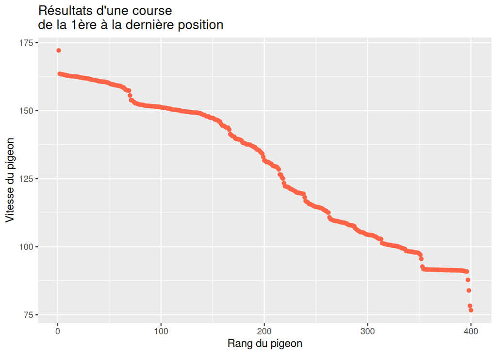

```r
library(ggplot2)

ggplot(pigeon, aes(x = Pos, y = Vitesse)) +
  geom_point(color='tomato') +
  xlab("Rang du pigeon") +
  ylab("Vitesse du pigeon") +
  ggtitle("Résultats d'une course \nde la 1ère à la dernière position")
```

# La production d’argent

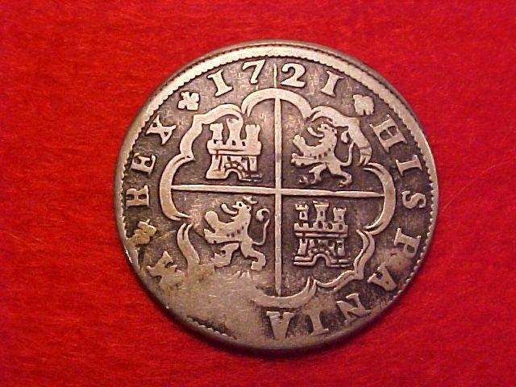

Figure 3: Real espagnol.

Les Espagnols ont gardé des registres très détaillés sur la quantité d’argent qu’ils produisaient à l’époque coloniale (1720 - 1800).

```r
argent <- readr::read_csv("data/argent.csv")

argent

str(argent)
```

[output not shown]

```r
argent$situados_payé_g <- argent$situados_payé * argent$guerre_ind_américaine
argent$argent_frappé_g <- argent$argent_frappé * argent$guerre_ind_américaine

argent
```

[output not shown]

## La quantité d’argent frappé

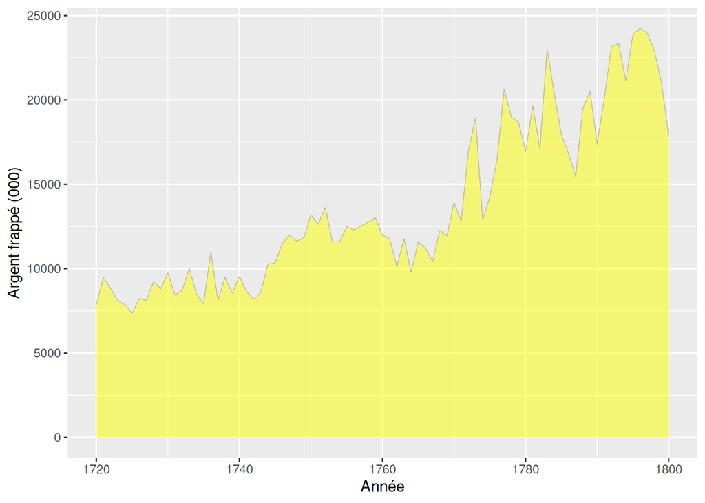

Figure 4: Quantité d’argent frappé.

```r
library(ggplot2)

ggplot(argent, aes(x = année, y = argent_frappé/1000)) +
  geom_area(colour = 'darkgray', size = 0.2, fill = 'yellow', alpha = 0.5) +
  xlab("Année") +
  ylab("Argent frappé (000)")
```

Voyons l’effet de la guerre d’Indépendance américaine. La Déclaration d’Indépendance a lieu en 1776 et la guerre prend fin en 1783.

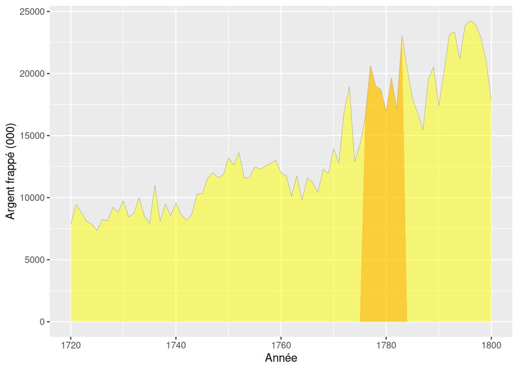

Figure 5: Quantité d’argent frappé.

```r
ggplot(argent, aes(x = année, y = argent_frappé/1000)) +
  geom_area(colour = 'darkgray', size = 0.2, fill = 'yellow', alpha = 0.5) +
  geom_area(aes(x = année, y = argent_frappé_g/1000), fill = 'orange', alpha = 0.5) +
  xlab("Année") +
  ylab("Argent frappé (000)")
```

Nous aurions pu illustrer l’effet inflationniste d’autres périodes de guerres:

- Guerre de Succession d’Autriche (1740-48).
- Guerre de Sept Ans dans les Amériques (1754-1760; en Europe, 1756-1763).
- Guerres suivant la Révolution française dont la Première Coalition (1792-1797).

## La quantité cumulative

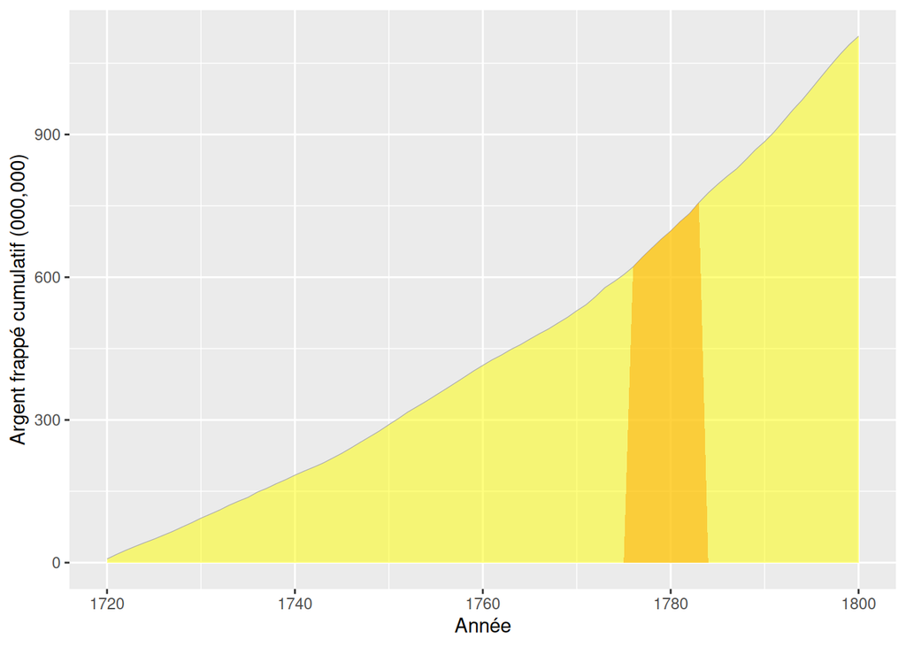

Figure 6: Quantité d’argent frappé.

```r
argent$argent_frappé_cum <- cumsum(argent$argent_frappé)
argent$argent_frappé_cum_g <- argent$argent_frappé_cum * argent$guerre_ind_américaine

ggplot(argent, aes(x = année, y = argent_frappé_cum/1000000)) +
  geom_area(colour = 'darkgray', size = 0.2, fill = 'yellow', alpha = 0.5) +
  geom_area(aes(x = année, y = argent_frappé_cum_g/1000000), fill = 'orange', alpha = 0.5) +
  xlab("Année")  +
  ylab("Argent frappé cumulatif (000,000)")
```

## Une superposition

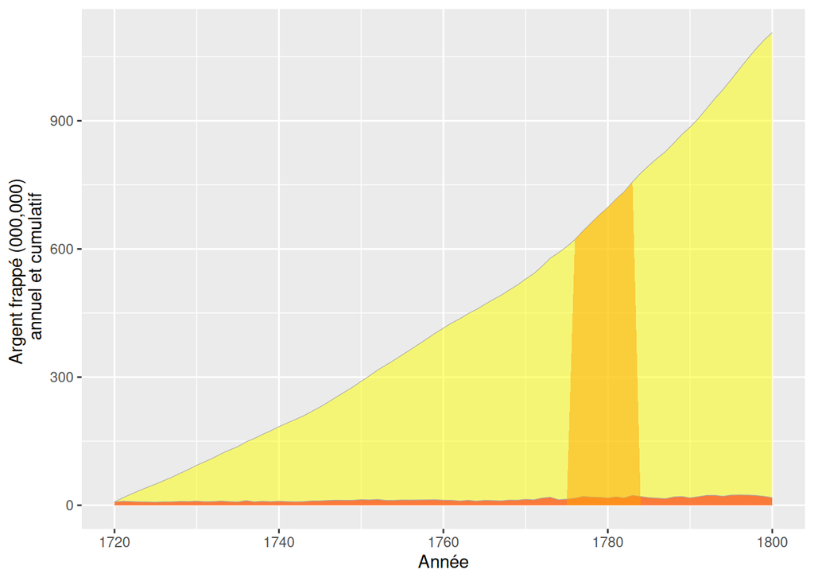

Figure 7: Quantité d’argent frappé.

```r
ggplot(argent) +
  geom_area(aes(x = année, y = argent_frappé_cum/1000000), colour = 'darkgray', size = 0.2, fill = 'yellow', alpha = 0.5) +
  geom_area(aes(x = année, y = argent_frappé/1000000), colour = 'darkgray', size = 0.2, fill = 'red', alpha = 0.5) +
  geom_area(aes(x = année, y = argent_frappé_cum_g/1000000), fill = 'orange', alpha = 0.5) +
  xlab("Année") +
  ylab("Argent frappé (000,000) \n annuel et cumulatif") +
  scale_fill_discrete() +
  theme(legend.position='upperleft')
```

## Avec un thème

Les thèmes prédéfinis sauvent du temps. Voyons le thème «The Economist».

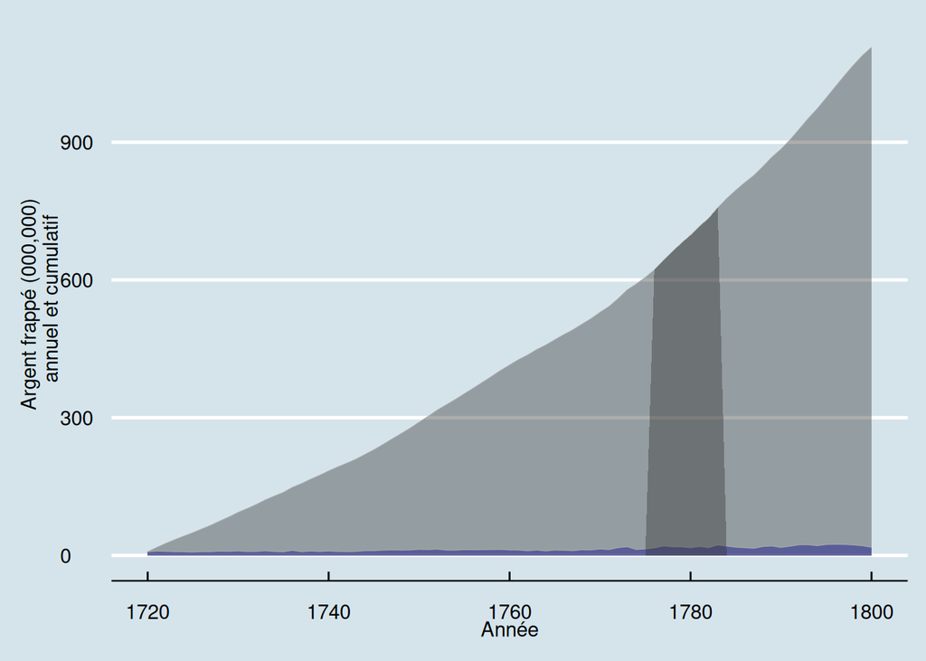

Figure 8: Quantité d’argent frappé.

```r
library(ggthemes)

ggplot(argent) +
  geom_area(aes(x = année, y = argent_frappé_cum/1000000), colour = 'darkgray', size = 0.2, alpha = 0.4) +
  geom_area(aes(x = année, y = argent_frappé/1000000), colour = 'darkgray', size = 0.2, fill = 'darkblue', alpha = 0.4) +
  geom_area(aes(x = année, y = argent_frappé_cum_g/1000000), alpha = 0.4) +
  xlab("Année") +
  ylab("Argent frappé (000,000) \n annuel et cumulatif") +
  theme_economist() +
  scale_colour_economist()
```